# Framingham Heart Study

Samer Alzaim

```r
data <- read.csv("https://raw.githubusercontent.com/sameralzaim/Project-3/main/FraminghamHeartStudy.csv",
                   header = TRUE, sep = ",", stringsAsFactors = FALSE)

#head (data, n=10)
```

# 1 Introducion

The Framingham Heart Study is a long-term, ongoing cardiovascular cohort study of residents of the city of Framingham, Massachusetts. The study began in 1948 with 5,209 adult subjects from Framingham, and is now on its third generation of participants.

The Framingham Heart Study was a landmark study in epidemiology in that it was the first prospective study of cardiovascular disease and identified the concept of risk factors and their joint effects FHS Longitudinal Data Document

More information about this long-term observational study can be found at https://nfb.org//sites/default/files/images/nfb/publications/vodold/vspr9804.htm

The goal is to make some predictive models on an FHS dataset and review some exploratory and modeling techniques

## 1.1 Itemized Variables List

The data consist of 4240 observations and 16 variables.

| **Variable** | **Description** | **Class** |
| --- | --- | --- |
| male | Gender | int |
| age | Age at the time of medical exam | int |
| education | Education level (4 levels) | int |
| currentSmoker | cigarette smoking | int |
| cigsPerDay | cigarettes smoked each day | int |
| BPMeds | Use of Anti-hypertensive | int |
| prevalentStroke | Prevalent Stroke (0 = No disease) | int |
| prevalentHyp | Subject defined as hypertensive | int |
| diabetes | Diabetic | int |
| totChol | Total cholesterol (mg/dL) | int |
| sysBP | Systolic Blood Pressure | num |
| diaBP | Diastolic blood pressure (mmHg) | num |
| BMI | Body Mass Index | num |
| heartRate | Heart rate | int |
| glucose | Blood glucose level | int |
| TenYearCHD | 10 year risk coronary heart disease | int |

## 1.2 Checking For Missing data

645 missing values in the database

majority of the missing values are the Glucose reading, however Glucose is indication of debates (> 125) and since we d not have any missing values in diabetes variable, we are not overly concerns with this missing values.

Additionally, for this and rest of missing value, trees are good in handling and accounting for missing values, hence, we will proceed without imputing the missing values.

```r
# sum (is.na(data))

colSums(is.na(data))
```

```
           male             age       education   currentSmoker      cigsPerDay
              0               0             105               0              29
         BPMeds prevalentStroke    prevalentHyp        diabetes         totChol
             53               0               0               0              50
          sysBP           diaBP             BMI       heartRate         glucose
              0               0              19               1             388
     TenYearCHD
              0
```

## 1.3 Data Distribution & Outliers

🟦 Education: Most people are in level 1 (1720), fewest in level 4 (473). Skewed toward lower education levels

🟦 Diabetes: Majority of people are diabetes free, 4131 out of 4240.

🟦 TenYearCHD: About 15% had CHD — relatively rare outcome

🟦 Smokers: Half the population smokes or used to smoke

🟦 BPMeds (Blood Pressure Medications): Very few are on BP meds (~3%).

🟦 PrevalentStroke: Extremely rare in the dataset (~0.6%).

🟦 PrevalentHyp (Hypertension): About 31% have high blood pressure

[figure not shown]

```r
layout(matrix(1:8, nrow = 2), widths = c(1, 1, 1, 1))
# Create a frequency table Gender
male_counts <- table(data$male)

# Make the barplot and capture the midpoints of bars
bp <- barplot(male_counts,
              main = "Distributio by Gender",
              col = "skyblue",
              xlab = "Gender",
              ylim = c(0, max(male_counts) * 1.2))  # Add a little space for the labels

# Add the text labels (counts)
text(x = bp, y = male_counts, labels = male_counts, pos = 3, cex = 0.9)


# Create a frequency table
CS_counts <- table(data$currentSmoker)

# Make the barplot and capture the midpoints of bars
bp <- barplot(CS_counts,
              main = "Distribution by Smoker",
              col = "skyblue",
              xlab = "Smoker",
              ylim = c(0, max(CS_counts) * 1.2))  # Add a little space for the labels

# Add the text labels (counts)
text(x = bp, y = CS_counts, labels = CS_counts, pos = 3, cex = 0.9)


# Create a frequency table
education_counts <- table(data$education)

# Make the barplot and capture the midpoints of bars
bp <- barplot(education_counts,
              main = "Distribution by Education",
              col = "skyblue",
              xlab = "Education",
              ylim = c(0, max(education_counts) * 1.2))  # Add a little space for the labels

# Add the text labels (counts)
text(x = bp, y = education_counts, labels = education_counts, pos = 3, cex = 0.9)

# Create a frequency table
BPMeds_counts <- table(data$BPMeds)

# Make the barplot and capture the midpoints of bars
bp <- barplot(BPMeds_counts,
              main = "Distribution by BPMeds",
              col = "skyblue",
              xlab = "BPMeds",
              ylim = c(0, max(BPMeds_counts) * 1.4))  # Add a little space for the labels

# Add the text labels (counts)
text(x = bp, y = BPMeds_counts, labels = BPMeds_counts, pos = 3, cex = 0.9)

# Create a frequency table
diabetes_counts <- table(data$diabetes)

# Make the barplot and capture the midpoints of bars
bp <- barplot(diabetes_counts,
              main = "Distribution by diabetes",
              col = "skyblue",
              xlab = "diabetes",
              ylim = c(0, max(diabetes_counts) * 1.2))  # Add a little space for the labels

# Add the text labels (counts)
text(x = bp, y = diabetes_counts, labels = diabetes_counts, pos = 3, cex = 0.9)

# Create a frequency table
prevalentStroke_counts <- table(data$prevalentStroke)

# Make the barplot and capture the midpoints of bars
bp <- barplot(prevalentStroke_counts,
              main = "Distribution by Preventive Stroke",
              col = "skyblue",
              xlab = "prevalentStroke",
              ylim = c(0, max(prevalentStroke_counts) * 1.2))  # Add a little space for the labels

# Add the text labels (counts)
text(x = bp, y = prevalentStroke_counts, labels = prevalentStroke_counts, pos = 3, cex = 0.9)


# Create a frequency table
TenYearCHD_counts <- table(data$TenYearCHD)

# Make the barplot and capture the midpoints of bars
bp <- barplot(TenYearCHD_counts,
              main = "Distribution by 10Years Education",
              col = "navy",
              xlab = "TenYearCHD",
              ylim = c(0, max(TenYearCHD_counts) * 1.2))  # Add a little space for the labels

# Add the text labels (counts)
text(x = bp, y = TenYearCHD_counts, labels = TenYearCHD_counts, pos = 3, cex = 0.9)

# Create a frequency table
prevalentHyp_counts <- table(data$prevalentHyp)

# Make the barplot and capture the midpoints of bars
bp <- barplot(BPMeds_counts,
              main = "Distribution by prevalentHyp",
              col = "skyblue",
              xlab = "prevalentHyp",
              ylim = c(0, max(prevalentHyp_counts) * 1.4))  # Add a little space for the labels

# Add the text labels (counts)
text(x = bp, y = prevalentHyp_counts, labels = prevalentHyp_counts, pos = 3, cex = 0.9)
```

Some variables (like diabetes, stroke, and BP meds) are highly imbalanced, which can affect modeling (especially classification models like logistic regression or decision trees).

Class imbalance may require techniques like resampling, weighting, or threshold tuning.

CHD (the target variable) is imbalanced but not extreme (~15%).

```r
# Load required library
library(plotly)

# Create individual interactive boxplots
p1 <- plot_ly(data, y = ~heartRate, type = "box", name = "heartRate", boxpoints = "outliers", marker = list(color = "brown2"))
p2 <- plot_ly(data, y = ~sysBP, type = "box", name = "sysBP", boxpoints = "outliers", marker = list(color = "purple1"))
p3 <- plot_ly(data, y = ~totChol, type = "box", name = "totChol", boxpoints = "outliers", marker = list(color = "cyan4"))
p4 <- plot_ly(data, y = ~glucose, type = "box", name = "glucose", boxpoints = "outliers", marker = list(color = "brown2"))


# Arrange them in a single row using subplot
subplot(p1, p2, p3, p4, nrows = 1, shareY = FALSE, titleX = TRUE)
```

[interactive chart not shown]

🟦 Heart Rate: Many values above ~100, with a few >140 (likely high resting HRs)

🟧 sysBP (Systolic Blood Pressure): Many above 180–250, some extreme values ~300+. High number of systolic BP outliers could indicate hypertension cases or data entry errors.

🟩 Total Cholesterol: Outliers: Several values >400 and even up to 700+. Cholesterol levels above 240 are considered high — this data may have individuals at cardiovascular risk.

🟥 Glucose: Large number of outliers above 125, going up to 400. Glucose >126 mg/dL is diagnostic for diabetes — data has many such high values.

```r
# Load required library
library(plotly)

# Create individual interactive boxplots
p1 <- plot_ly(data, y = ~cigsPerDay, type = "box", name = "cigsPerDay", boxpoints = "outliers", marker = list(color = "brown2"))
p2 <- plot_ly(data, y = ~age, type = "box", name = "age", boxpoints = "outliers", marker = list(color = "purple1"))
p3 <- plot_ly(data, y = ~BMI, type = "box", name = "BMI", boxpoints = "outliers", marker = list(color = "green3 "))
p4 <- plot_ly(data, y = ~diaBP, type = "box", name = "diaBP", boxpoints = "outliers", marker = list(color = "green3"))


# Arrange them in a single row using subplot
subplot(p1, p2, p3,p4, nrows = 1, shareY = FALSE, titleX = TRUE)
```

[interactive chart not shown]

🟦 Cigarettes per Day: Most people smoke little or not at all, but there’s a tail of heavy smokers.

🟧 Age: Age distribution is fairly centered in middle-aged adults, with no major outliers

🟩 Body Mass Index (BMI): Majority of the data lies in the healthy to overweight range, but a noticeable number of people are in the obese range (BMI > 30).

🟥 Diastolic Blood Pressure: Many individuals have elevated diastolic BP. High count of outliers suggests possible hypertensive cases needing attention

**The below scatter plot shows the relationship between glucose and diabetes**

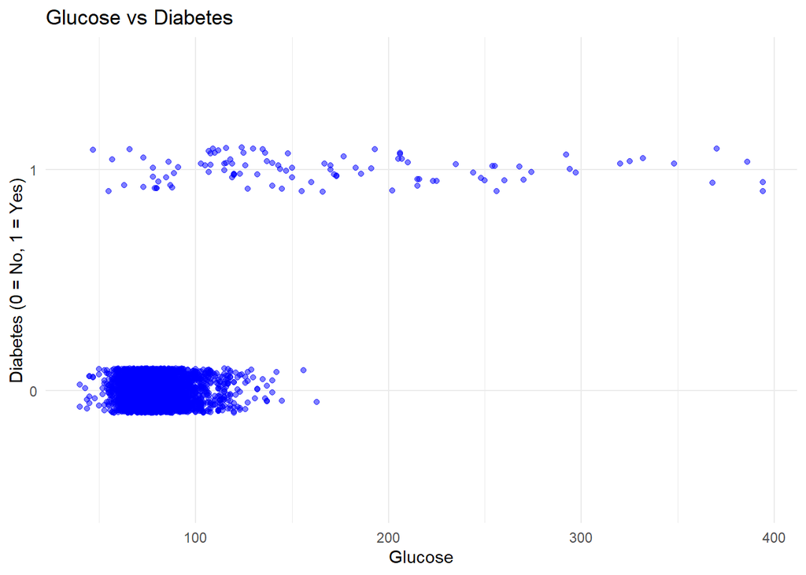

```r
library(ggplot2)

ggplot(data, aes(x = glucose, y = as.factor(diabetes))) +
  geom_jitter(width = 0, height = 0.1, alpha = 0.5, color = "blue") +
  labs(
    title = "Glucose vs Diabetes",
    x = "Glucose",
    y = "Diabetes (0 = No, 1 = Yes)"
  ) +
  theme_minimal()
```

From the above scatter plot =, we can see that majority, almost all, of the persons not diagnosed with diabetes have glucose < 125. similarly we can see that majority of people diagnosed with diabetes have glucose > 125

# 2 Predicting Cardiovascular Desease CHD

To predict and calculate class variable, we use Classification trees. Classification trees are a type of supervised learning algorithm that recursively partitions the feature space to predict categorical target variables.

## 2.1 Grow Initial Tree

The initial tree size is controlled by some default hyper-parameters “rpart.control()”. It tends to be over-fitted.

While it is common in classification that the key challenge is that the classes (categories) are not equally represented. Our response variable have 644 observations with yes and 3596 observations with no.

A we are building the tree, we start with the entire dataset at the root node and then recursively split the data into purer subsets

Optimal Tree Size: Typically where xerror is minimized

```r
# Step 2: Split data into training and test sets
set.seed(12345)
train.index <- createDataPartition(data$TenYearCHD, p = 0.7, list = FALSE)
train.data <- data[train.index, ]
test.data <- data[-train.index, ]

# Step 3: Fit the classification tree using the new binary target

tree.model <- rpart(TenYearCHD ~ .,
                    data = train.data[, !(names(train.data) %in% "class")],  # drop original class
                    method = "class",   # classification tree
                    parms = list(split = "gini",  # Using Gini index
                                 # FN cost = 1, FP cost = 0.5
                                 loss = matrix(c(0, 0.5, 1, 0), nrow = 2)
                                 ),
                    control = rpart.control(minsplit = 20,  # Min 15 obs to split
                                           minbucket = 10,   # Min 7 obs in leaf
                                           # Complexity parameter
                                           cp = 0.001, # complex parameter
                                           maxdepth = 7))   # Max tree depth
```

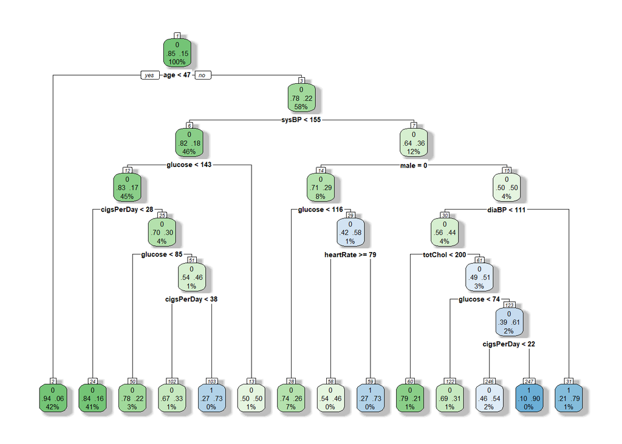

```r
rpart.plot(tree.model,
           extra = 104, # check the help document for more information
           # color palette is a sequential color scheme that blends green (G) to blue (Bu)
           box.palette = "GnBu",
           branch.lty = 1,
           shadow.col = "gray",
           nn = TRUE)
```

## 2.2 Pruning Tree

```r
#Print the complexity parameter table
pander(tree.model$cptable)
```

| CP | nsplit | rel error | xerror | xstd |
| --- | --- | --- | --- | --- |
| 0.003898 | 0 | 1 | 2 | 0.08695 |
| 0.002227 | 7 | 0.9688 | 1.964 | 0.0855 |
| 0.001114 | 9 | 0.9644 | 1.973 | 0.08561 |
| 0.001 | 13 | 0.9599 | 1.971 | 0.08548 |

The below graph gives the reference line (broken line) for 1-SE rule. The numbers on the top of the plot represent the leaf nodes in the final tree diagram.

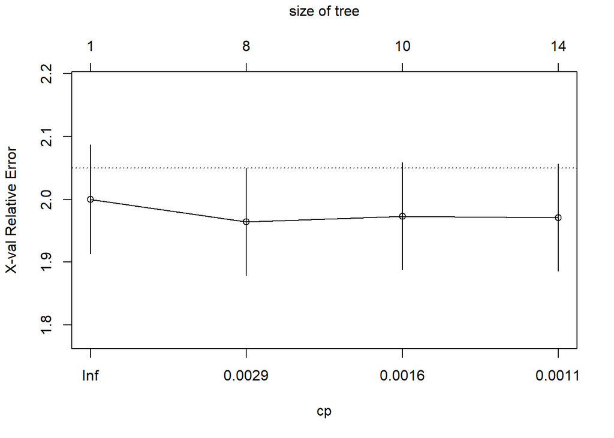

```r
# Print cp table
#printcp(tree.model)

# Plot cp vs cross-validated error
plotcp(tree.model)
```

For clarity in the analysis, we introduce two notations: min.cp represents the cp value yielding the minimum cross-validation error, while 1SE.cp denotes the cp value selected by the more conservative 1-SE rule (minimal error plus one standard error).

[figure not shown]

```r
# Find the optimal cp value that minimizes cross-validated error
min.cp <- tree.model$cptable[which.min(tree.model$cptable[,"xerror"]),"CP"]

# Prune the tree using the optimal cp
pruned.tree.1SE <- prune(tree.model, cp = 0.001)
pruned.tree.min <- prune(tree.model, cp = min.cp)

# Visualize the pruned tree
rpart.plot(pruned.tree.1SE,
           extra = 104, # check the help document for more information
           # color palette is a sequential color scheme that blends green (G) to blue (Bu)
           box.palette = "GnBu",
           branch.lty = 1,
           shadow.col = "navy",
           nn = TRUE,
           main = "Pruned Classification Tree (1-SE Rule)")
```

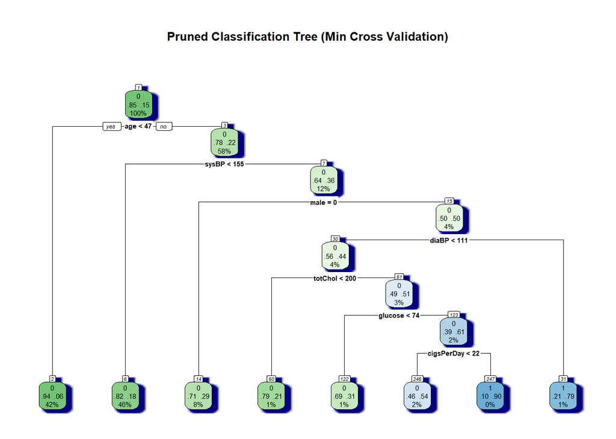

```r
# Visualize the pruned tree
rpart.plot(pruned.tree.min,
           extra = 104, # check the help document for more information
           # color palette is a sequential color scheme that blends green (G) to blue (Bu)
           box.palette = "GnBu",
           branch.lty = 1,
           shadow.col = "navy",
           nn = TRUE,
           main = "Pruned Classification Tree (Min Cross Validation)")
```

## 2.3 Global Performance with ROC

Classification trees make predictions by routing observations through a series of hierarchical splits, starting at the root node and ending at a terminal leaf node. Each split applies a decision rule based on feature values.

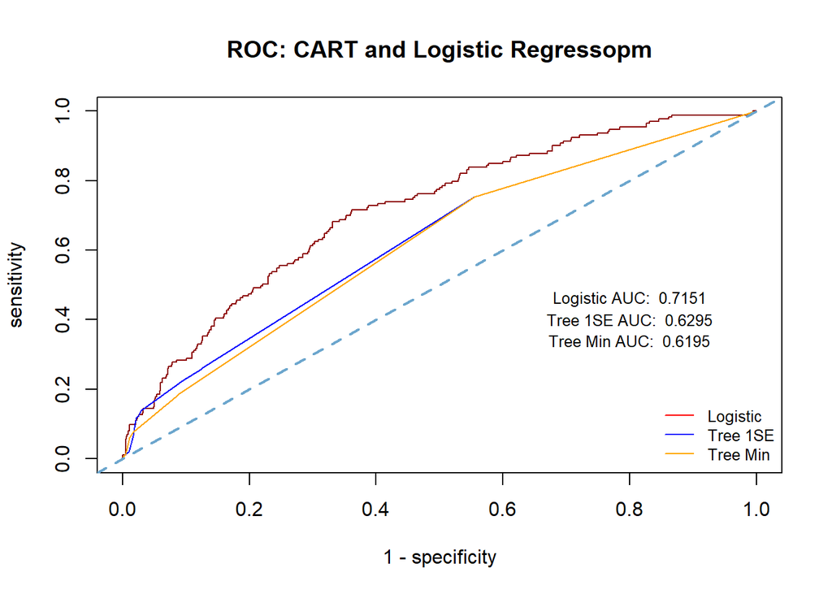

```r
# Make predictions on the test set
pred.label.1SE <- predict(pruned.tree.1SE, test.data, type = "class") # default cutoff 0.5
pred.prob.1SE <- predict(pruned.tree.1SE, test.data, type = "prob")[,2]
##
pred.label.min <- predict(pruned.tree.min, test.data, type = "class") # default cutoff 0.5
pred.prob.min <- predict(pruned.tree.min, test.data, type = "prob")[,2]

# Confusion matrix
#conf.matrix <- confusionMatrix(pred.label, test.data$TenYearCHD, positive = "pos")
#print(conf.matrix)

train.data$TenYearCHD <- data$TenYearCHD[train.index]
test.data$TenYearCHD <- data$TenYearCHD[-train.index]

# Remove rows with any NA
train.data.clean <- na.omit(train.data)

########################
###  logistic regression
logit.fit <- glm(TenYearCHD ~ ., data = train.data.clean, family = binomial)
AIC.logit <- step(logit.fit, direction = "both", trace = 0)
pred.logit <- predict(AIC.logit, test.data, type = "response")

# ROC curve and AUC
roc.tree.1SE <- roc(test.data$TenYearCHD, pred.prob.1SE)
roc.tree.min <- roc(test.data$TenYearCHD, pred.prob.min)
roc.logit <- roc(test.data$TenYearCHD, pred.logit)

##
### Sen-Spe
tree.1SE.sen <- roc.tree.1SE$sensitivities
tree.1SE.spe <- roc.tree.1SE$specificities
#
tree.min.sen <- roc.tree.min$sensitivities
tree.min.spe <- roc.tree.min$specificities

#
logit.sen <- roc.logit$sensitivities
logit.spe <- roc.logit$specificities
## AUC
auc.tree.1SE <- roc.tree.1SE$auc
auc.tree.min <- roc.tree.min$auc
auc.logit <- roc.logit$auc

###
plot(1-logit.spe, logit.sen,
     xlab = "1 - specificity",
     ylab = "sensitivity",
     col = "darkred",
     type = "l",
     lty = 1,
     lwd = 1,
     main = "ROC: CART and Logistic Regressopm")
lines(1-tree.1SE.spe, tree.1SE.sen,
      col = "blue",
      lty = 1,
      lwd = 1)
lines(1-tree.min.spe, tree.min.sen,
      col = "orange",
      lty = 1,
      lwd = 1)
abline(0,1, col = "skyblue3", lty = 2, lwd = 2)
legend("bottomright", c("Logistic", "Tree 1SE", "Tree Min"),
       lty = c(1,1,1), lwd = rep(1,3),
       col = c("red", "blue", "orange"),
       bty="n",cex = 0.8)
## annotation - AUC
text(0.8, 0.46, paste("Logistic AUC: ", round(auc.logit,4)), cex = 0.8)
text(0.8, 0.4, paste("Tree 1SE AUC: ", round(auc.tree.1SE,4)), cex = 0.8)
text(0.8, 0.34, paste("Tree Min AUC: ", round(auc.tree.min,4)), cex = 0.8)
```

## 2.4 Optimal Cut-off Probability

To get the performance of the tree, we need to choose the otimla cut off model as classification trees provide us with binary classification either 0 or 1, yea or no, deceased or not deceased…etc. The choice of this threshold significantly impacts model performance, as it balances accuracy, sensitivity , and specificity.

I. Trade-off Between Sensitivity and Specificity II. Accuracy-Driven Cut-off III. Cost-Sensitive Threshold IV. ROC and Precision-Recall Curves V. Practical Considerations

### 2.4.1 Cut-off Versus Misclassification Cost

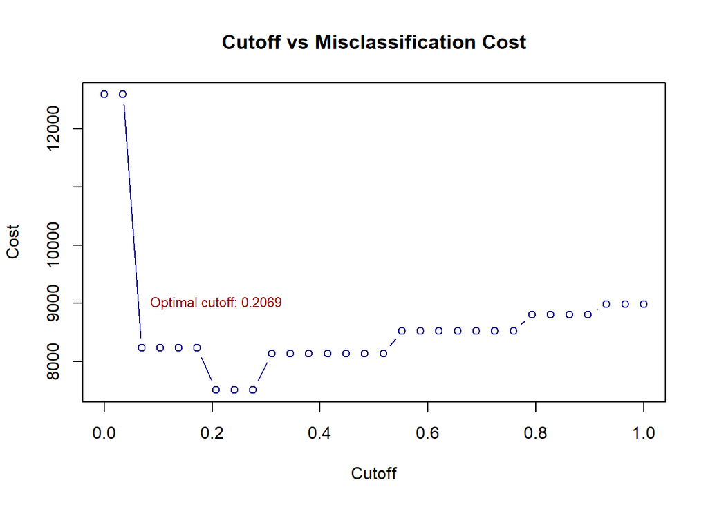

```r
# Predictive probabilities of the pruned tree
pred.prob.min <- predict(pruned.tree.min, train.data, type = "prob")[, 2]

# Cutoff values
cutoff <- seq(0, 1, length = 30)
cost <- numeric(length(cutoff))

# Misclassification cost for each cutoff
for (i in seq_along(cutoff)) {
  pred.label <- ifelse(pred.prob.min > cutoff[i], 1, 0)
  FN <- sum(pred.label == 0 & train.data$TenYearCHD == 1)
  FP <- sum(pred.label == 1 & train.data$TenYearCHD == 0)
  cost[i] <- 5 * FP + 20 * FN
}

# Optimal cutoff
min.ID <- which(cost == min(cost))
optim.prob <- mean(cutoff[min.ID])

# Plot
plot(cutoff, cost, type = "b", col = "navy",
     main = "Cutoff vs Misclassification Cost",
     xlab = "Cutoff", ylab = "Cost")
text(optim.prob, min(cost) *1.2,
     paste("Optimal cutoff:", round(optim.prob, 5)),
     cex = 0.8, col = "darkred")
```

# 3 Predicting Systemic Blood Presure

This process requires multiple steps as follows:

## 3.1 Tree induction

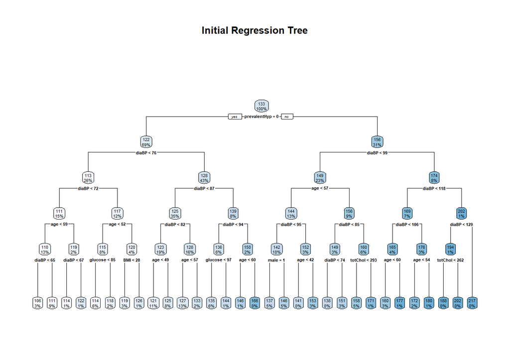

```r
# Set seed for reproducibility
set.seed(12345)


# Split data into training (70%) and test (30%) sets
train.index <- sample(1:nrow(data), size = 0.7 * nrow(data))
train.data <- data[train.index, ]
test.data <- data[-train.index, ]

# 1. Tree Induction & 2. Splitting Criteria
# Build the initial regression tree using rpart
tree.model <- rpart(sysBP ~ .,
                    data = train.data,
                    method = "anova",     # For regression
                    control = rpart.control(
                      minsplit = 20,    # 3. Stopping rule: min observations to split
                      minbucket = 10,    # Min observations in terminal node
                      cp = seq(0, 0.05, 20), # Complexity parameter
                      maxdepth = 5      # Maximum tree depth
                    ))

# Visualize the unpruned tree
rpart.plot(tree.model, main = "Initial Regression Tree")
```

The above initial tree contains a long list of different nodes. However, we can use these information / nodes to improve the initial tree model.

In order to improve the tree, wee look at the model complexity parameter cp and related errors and appropriately prune the initial tree.

## 3.2 Pruning Tree

The below complexity table shows key information we need for our tree pruning based on cross-validation:

- Complexity parameter values: Penalty term that balances tree complexity with fit quality
- Number of splits in the Tree (nsplit)
- Relative error (rel error) Calculated as: Error(current_tree)/Error(root_node)
- Cross-validated error (xerror)
- Standard error of the cross-validated error (xstd)

```r
# Examine cross-validation results
pander(tree.model$cptable)
```

| CP | nsplit | rel error | xerror | xstd |
| --- | --- | --- | --- | --- |
| 0.4834 | 0 | 1 | 1.001 | 0.03879 |
| 0.07509 | 1 | 0.5166 | 0.5171 | 0.02326 |
| 0.06586 | 2 | 0.4416 | 0.4503 | 0.01892 |
| 0.02506 | 3 | 0.3757 | 0.3846 | 0.01816 |
| 0.02301 | 4 | 0.3506 | 0.3665 | 0.01792 |
| 0.01458 | 5 | 0.3276 | 0.3344 | 0.01478 |
| 0.005884 | 6 | 0.313 | 0.3131 | 0.01355 |
| 0.004967 | 7 | 0.3072 | 0.3101 | 0.0132 |
| 0.004861 | 8 | 0.3022 | 0.3092 | 0.01318 |
| 0.004328 | 9 | 0.2973 | 0.3052 | 0.01308 |
| 0.004247 | 11 | 0.2887 | 0.3042 | 0.013 |
| 0.003947 | 12 | 0.2844 | 0.3007 | 0.0129 |
| 0.003391 | 13 | 0.2805 | 0.2966 | 0.01289 |
| 0.002879 | 14 | 0.2771 | 0.2955 | 0.01285 |
| 0.002758 | 15 | 0.2742 | 0.296 | 0.01294 |
| 0.00241 | 16 | 0.2715 | 0.2957 | 0.01294 |
| 0.00203 | 17 | 0.2691 | 0.2956 | 0.0129 |
| 0.001777 | 18 | 0.267 | 0.2967 | 0.01295 |
| 0.001595 | 19 | 0.2652 | 0.2951 | 0.01282 |
| 0.001389 | 20 | 0.2636 | 0.2928 | 0.01226 |
| 0.001385 | 21 | 0.2623 | 0.2935 | 0.01225 |
| 0.001252 | 22 | 0.2609 | 0.2936 | 0.01224 |
| 0.001183 | 23 | 0.2596 | 0.2935 | 0.01225 |
| 0.001139 | 24 | 0.2584 | 0.2926 | 0.01222 |
| 0.000911 | 25 | 0.2573 | 0.2924 | 0.0122 |
| 0.0008575 | 26 | 0.2564 | 0.2927 | 0.01221 |
| 0.0005992 | 27 | 0.2555 | 0.2935 | 0.01224 |
| 0.0004833 | 28 | 0.2549 | 0.2944 | 0.01224 |
| 0.000467 | 29 | 0.2545 | 0.2942 | 0.01221 |
| 0 | 30 | 0.254 | 0.2941 | 0.0122 |

from the above, we can see that min Cross validation error is 0.2924 with number of splits of 25 abd cp of 0.000911.

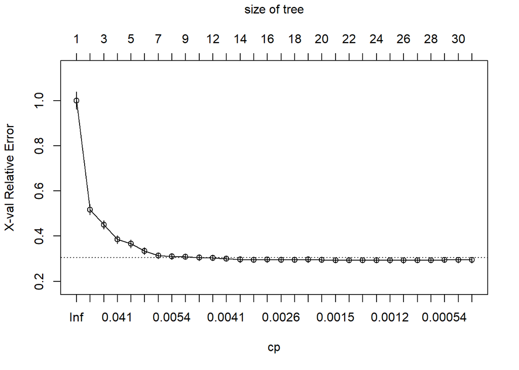

```r
plotcp(tree.model)
```

## 3.3 Selecting Optimal Tree

To select the optimal rtree, we choose, the smallest number of splits (nsplit) where cross validation error (xerror) is within 1 standard deviation (xstd) of the minimum CP.

in the table represent 0.2924 with nsplit of 25. We need to identify the largest CP where xerror is within 1 standard error of the minimum (to balance simplicity and accuracy). the graph entails the the cp within 1SE of the min cp is 0.0042

```r
cp.table <- tree.model$cptable

## Identify the minimum `xerror` and its `cp`.
min.xerror <- min(cp.table[, "xerror"])
min.cp.row <- which.min(cp.table[, "xerror"])
min.cp <- cp.table[min.cp.row, "CP"]

## Get the standard error (`xstd`) of the minimum `xerror`
xerror.std <- cp.table[min.cp.row, "xstd"]
threshold <- min.xerror + xerror.std  # Upper bound (1 SE rule)

## Find the simplest tree (`cp`) Where `xerror less than or equal to Threshold`.
best.cp.row <- which(cp.table[, "xerror"] <= threshold)[1]  # First row meeting criteria
best.cp <- cp.table[best.cp.row, "CP"]

## Two different trees: best CP vs minimum CP
pruned.tree.best.cp <- prune(tree.model, cp = best.cp)
pruned.tree.min.cp <- prune(tree.model, cp = min.cp)
```

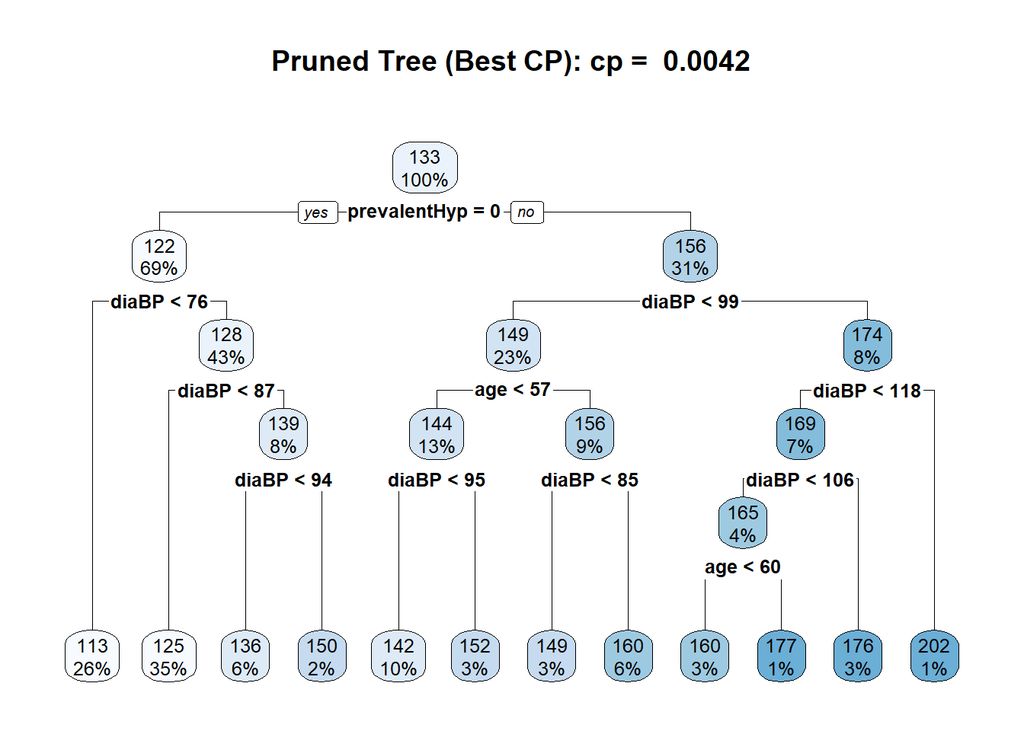

```r
# Visualize the pruned tree: best CP
rpart.plot(pruned.tree.best.cp, main = paste("Pruned Tree (Best CP): cp = ", round(best.cp,4)))
```

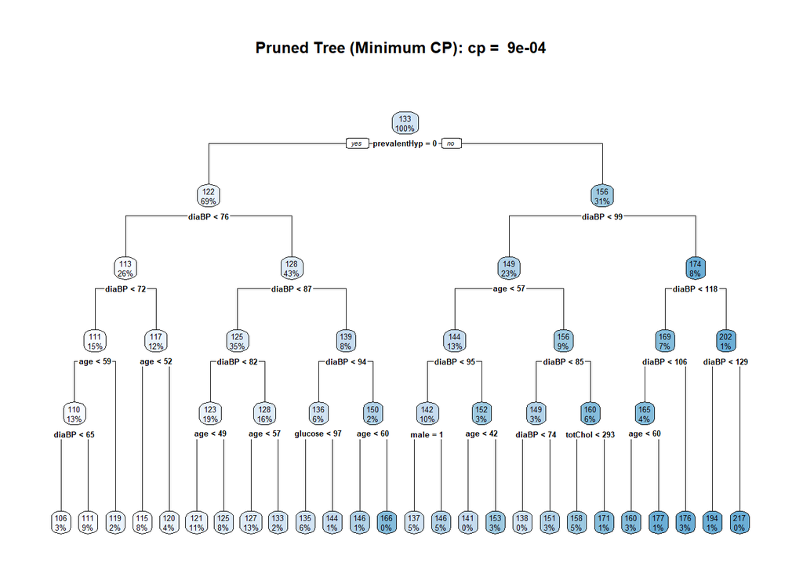

```r
# Visualize the pruned tree: minimum CP
rpart.plot(pruned.tree.min.cp, main = paste("Pruned Tree (Minimum CP): cp = ", round(min.cp,4)))
```

## 3.4 Building the linear regession model

As next step: we use the pruned regression tree with best and min cp to make predictions and since we did not use all variables, we fit fit two linear regression models and compare the performance of the three models.

The 2 linear regression models were built as follows:

LSE01: includes “diaBP + prevalentHyp + age”. LSE02: including all variables through step-wise variable selection.

```r
# 5. Prediction
# Make predictions on test data
pred.best.cp <- predict(pruned.tree.best.cp, newdata = test.data)
pred.min.cp <- predict(pruned.tree.min.cp, newdata = test.data)


# Evaluate model performance: best.cp
mse.tree.best.cp <- mean((test.data$sysBP - pred.best.cp)^2)
rmse.tree.best.cp <- sqrt(mse.tree.best.cp)
r.squared.tree.best.cp <- cor(test.data$sysBP, pred.best.cp)^2
# min.cp
mse.tree.min.cp <- mean((test.data$sysBP - pred.min.cp)^2)
rmse.tree.min.cp <- sqrt(mse.tree.min.cp)
r.squared.tree.min.cp <- cor(test.data$sysBP, pred.min.cp)^2

# Remove rows with any NA
train.data.clean <- na.omit(train.data)
test.data.clean <- test.data[, colnames(train.data.clean)]
test.data.clean <- na.omit(test.data.clean)

##
# fit ordinary least square regression
LSE01 <- lm(sysBP ~ diaBP + prevalentHyp + age, data = train.data)
pred.lse01 <-  predict(LSE01, newdata = test.data)
mse.lse01 <- mean((test.data$sysBP - pred.lse01)^2)
rmse.lse01 <- sqrt(mse.lse01)
r.squared.lse01 <- cor(test.data$sysBP, pred.lse01)^2

##
## ordinary LSE regression model with step-wise variable selection
lse02.fit <- lm(sysBP~.,data = train.data.clean)
AIC.fit <- stepAIC(lse02.fit, direction="both", trace = FALSE)
pred.lse02 <- predict(AIC.fit, test.data.clean)
mse.lse02 <- mean((test.data.clean$sysBP - pred.lse02)^2)    # mean square error
rmse.lse02 <- sqrt(mse.lse02)                       # root mean square error
r.squared.lse02 <- (cor(test.data.clean$sysBP, pred.lse02))^2 # r-squared

###
Errors <- cbind(MSE = c(mse.tree.best.cp, mse.tree.min.cp, mse.lse01, mse.lse02),
                RMSE = c(rmse.tree.best.cp, rmse.tree.min.cp, rmse.lse01, rmse.lse02),
                r.squared = c(r.squared.tree.best.cp, r.squared.tree.min.cp, r.squared.lse01, r.squared.lse02))
rownames(Errors) = c("tree.best.cp", "tree.min.cp", "lse01", "lse02")
pander(Errors)
```

|  | MSE | RMSE | r.squared |
| --- | --- | --- | --- |
| **tree.best.cp** | 144.3 | 12.01 | 0.6888 |
| **tree.min.cp** | 137.7 | 11.73 | 0.7033 |
| **lse01** | 129.9 | 11.4 | 0.7198 |
| **lse02** | 129.6 | 11.39 | 0.7267 |

## 3.5 Variable importance Best CP

Variable importance in regression trees identifies which predictors have the strongest influence on the target variable’s predictions

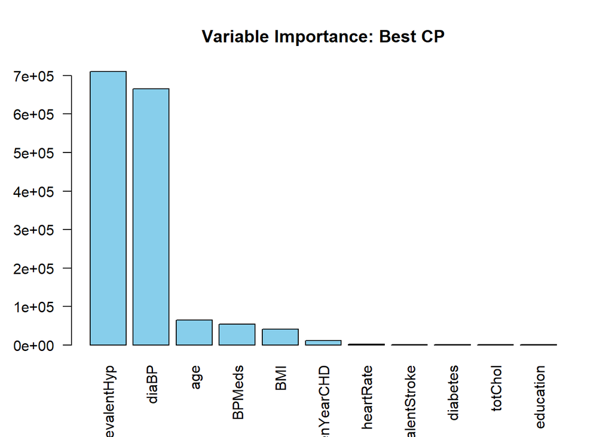

```r
importance <- pruned.tree.best.cp$variable.importance
barplot(sort(importance, decreasing = TRUE),
        main = "Variable Importance: Best CP",
        col = "skyblue",
        las = 2)
```

## 3.6 Variable importance Minimum CP

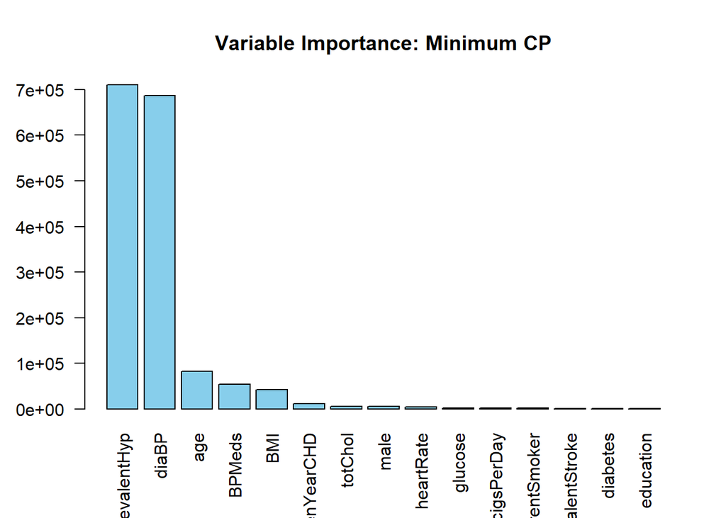

```r
importance <- pruned.tree.min.cp$variable.importance
barplot(sort(importance, decreasing = TRUE),
        main = "Variable Importance: Minimum CP",
        col = "skyblue",
                las = 2)
```

looking at the above tree we can see that some variables have higher importance are showing in the tree.

For comparison, we also print out the inferential table of the step-wise linear regression model in the following.

```r
pander(summary(AIC.fit)$coef)
```

|  | Estimate | Std. Error | t value | Pr(>\|t\|) |
| --- | --- | --- | --- | --- |
| **(Intercept)** | 14.71 | 2.859 | 5.144 | 2.891e-07 |
| **male** | -3.453 | 0.4706 | -7.337 | 2.919e-13 |
| **age** | 0.4122 | 0.02924 | 14.1 | 1.638e-43 |
| **education** | -0.8565 | 0.2225 | -3.85 | 0.0001211 |
| **currentSmoker** | 0.8099 | 0.4766 | 1.699 | 0.08936 |
| **BPMeds** | 6.504 | 1.358 | 4.791 | 1.754e-06 |
| **prevalentHyp** | 12.59 | 0.6466 | 19.47 | 8.039e-79 |
| **diaBP** | 1.067 | 0.02436 | 43.81 | 4.388e-313 |
| **heartRate** | 0.02981 | 0.0196 | 1.521 | 0.1284 |
| **glucose** | 0.05947 | 0.01001 | 5.939 | 3.255e-09 |
| **TenYearCHD** | 2.829 | 0.6597 | 4.289 | 1.864e-05 |

## 3.7 Conclusion

in the following steps, we will repeat the prediction that we have done above utilizing different Technics where wiil use bootstrap regression in calculating the and bootstrap aggregation in calculating CHD

# 4 Bootstrap Regression

Bootstrap methods are a class of resampling techniques used for statistical inference, particularly when theoretical distributions are complex or unknown. The bootstrap estimates the sampling distribution of a statistic by repeatedly resampling with replacement from the observed data and recalculating the statistic for each resample.

we will here attempt to recalcualte botthe Systemic Blood presure and the 10 Years Cardio Vascualr Deases using Bootstrap Regression.

## 4.1 Bootstrap Sampling Distribution

we fisrt looks at teh distribution of both variables using boostrap sampling:

### 4.1.1 10 Years THD

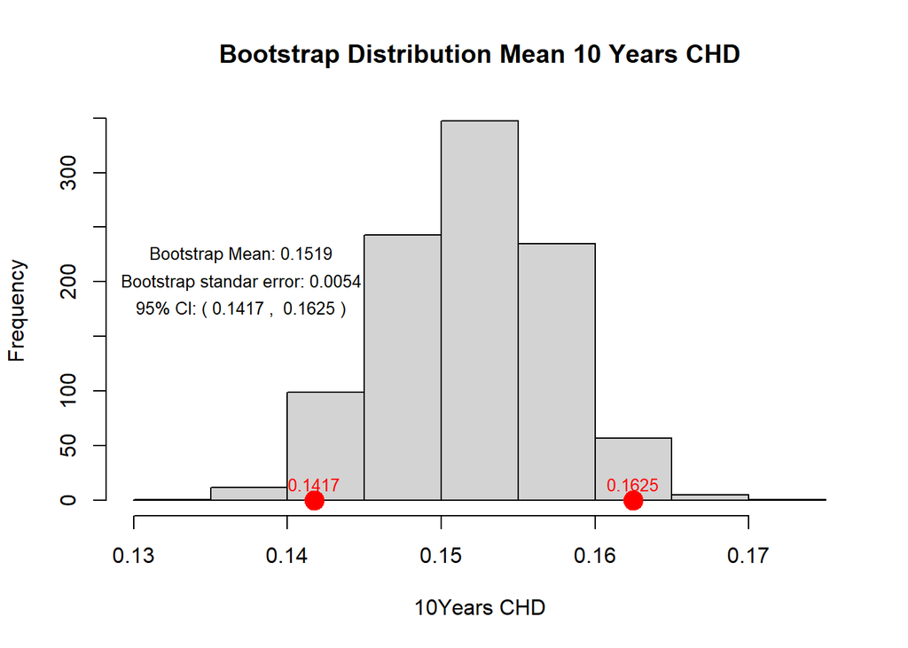

```r
CHD <- data$TenYearCHD  # Median home values

# Set seed for reproducibility
set.seed(12345)

# Generate B = 1000 bootstrap samples
B <- 1000
boot_means <- replicate(B, mean(sample(CHD, replace = TRUE)))

# Compare bootstrap vs. theoretical results
original_mean <- mean(CHD)
bootstrap_mean <- mean(boot_means)
bootstrap_se <- sd(boot_means)
CI <- quantile(boot_means, c(0.025, 0.975))
###
hist(boot_means, main = "Bootstrap Distribution Mean 10 Years CHD", xlab="10Years CHD")
text(0.137, 225, paste("Bootstrap Mean:", round(bootstrap_mean,4)), cex = 0.8)
text(0.137, 200, paste("Bootstrap standar error:", round(bootstrap_se,4)), cex = 0.8)
text(0.137, 175, paste("95% CI: (", round(CI[1],4), ", ", round(CI[2],4), ")"), cex = 0.8)
text(CI[1], 15, paste(round(CI[1],4)), cex = 0.8, col = "red")
text(CI[2], 15, paste(round(CI[2],4)), cex = 0.8, col = "red")

points(quantile(boot_means, c(0.025, 0.975)), c(0,0),
       pch=19, cex = 2, col = "red")
```

### 4.1.2 Systemic Blood Pressure

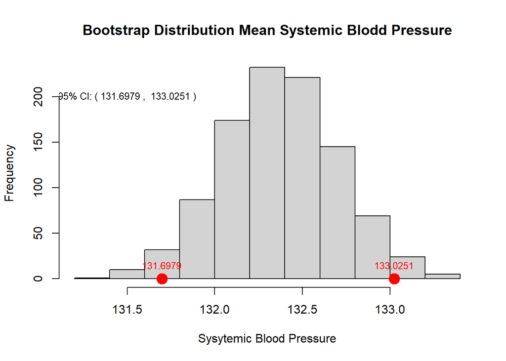

```r
sBP <- data$sysBP  # Median home values

# Set seed for reproducibility
set.seed(12345)

# Generate B = 1000 bootstrap samples
B <- 1000
boot_means <- replicate(B, mean(sample(sBP, replace = TRUE)))

# Compare bootstrap vs. theoretical results
original_mean <- mean(sBP)
bootstrap_mean <- mean(boot_means)
bootstrap_se <- sd(boot_means)
CI <- quantile(boot_means, c(0.025, 0.975))
###
hist(boot_means, main = "Bootstrap Distribution Mean Systemic Blodd Pressure", xlab="Sysytemic Blood Pressure")
text(131.5, 300, paste("Bootstrap Mean:", round(bootstrap_mean,4)), cex = 0.8)
text(131.5, 250, paste("Bootstrap standar error:", round(bootstrap_se,4)), cex = 0.8)
text(131.5, 200, paste("95% CI: (", round(CI[1],4), ", ", round(CI[2],4), ")"), cex = 0.8)
text(CI[1], 15, paste(round(CI[1],4)), cex = 0.8, col = "red")
text(CI[2], 15, paste(round(CI[2],4)), cex = 0.8, col = "red")

points(quantile(boot_means, c(0.025, 0.975)), c(0,0),
       pch=19, cex = 2, col = "red")
```

# 5 BAGGING Regression

The process involves generating multiple bootstrap samples from the training data, training individual regression trees on each subset, and aggregating their predictions—typically through averaging—to produce a more robust and stable regression model.

## 5.1 Hyperparameter Tuning

We calculate the values of the tuned hyperparamteres:

```r
# Split the data
set.seed(12345)
train.index <- createDataPartition(data$sysBP, p = 0.8, list = FALSE)
train.data <- data[train.index, ]
test.data <- data[-train.index, ]

# Set up train control for cross-validation
ctrl <- trainControl(
  method = "cv",
  number = 5,
  verboseIter = TRUE
)

# Define parameter combinations to test
nbagg.values <- c(10, 25, 50)     # number bagged trees
cp.values <- c(0.01, 0.05, 0.1)   # candidate cp values
maxdepth.values <- c(5, 10, 20)   # maximum depth of the candidate tree

# Create an empty data frame to store results
results <- data.frame()
######## Model tuning
# Manual tuning loop
for (nbagg in nbagg.values) {
  for (cp in cp.values) {
    for (maxdepth in maxdepth.values) {
      set.seed(123)
      model <- bagging(
        sysBP ~ .,
        data = train.data,
        nbagg = nbagg,
        coob = TRUE,
        trControl = ctrl,
        control = rpart.control(cp = cp,
                                maxdepth = maxdepth)
       )
      # Get OOB error from each iteration
      oob.error <- model$err
      # Store results
      results <- rbind(results,
                       data.frame( nbagg = nbagg,
                                   cp = cp,
                                   maxdepth = maxdepth,
                                   oob.error = oob.error))
    }
  }
}
# Find the best combination that yields the minimum out-of-bag's error
best.params <- results[which.min(results$oob.error), ]
pander(best.params)
```

|  | nbagg | cp | maxdepth | oob.error |
| --- | --- | --- | --- | --- |
| **19** | 50 | 0.01 | 5 | 12.19 |

## 5.2 Final Model Identification

We train the final bagging regression model. The model’s predictive performance is evaluated on the test set using standard error metrics, which are then compared against both the base regression tree and ordinary least squares (OLS) regression.

The following table summarizes the bagging model’s out-of-sample performance on the Framingham Heart Study dataset.

```r
final.model <- bagging(
  sysBP ~ .,
  data = train.data,
  nbagg = best.params$nbagg,
  coob = TRUE,
  trControl = ctrl,
  control = rpart.control(cp = best.params$cp,
                          maxdepth = best.params$maxdepth),

  importance = TRUE
)

# Evaluate on test set
predictions <- predict(final.model, newdata = test.data)
## Using the caret function to calculate errors across re-samples
baggedError <- postResample(pred = predictions, obs = test.data$sysBP)
pander(baggedError)
```

| RMSE | Rsquared | MAE |
| --- | --- | --- |
| 11.75 | 0.7051 | 8.749 |

## 5.3 Variable Importance

```r
var.imp <- varImp(final.model)
# Extract variable importance (requires a custom function)
get.bagging.importance <- function(model) {
  # Get all the trees from the bagging model
  trees <- model$mtrees

  # Initialize importance vector
  imp <- numeric(length(trees[[1]]$btree$variable.importance))
  names(imp) <- names(trees[[1]]$btree$variable.importance)

  # Sum importance across all trees
  for(tree in trees) {
    imp[names(tree$btree$variable.importance)] <-
      imp[names(tree$btree$variable.importance)] +
      tree$btree$variable.importance
  }

  # Average importance
  imp <- imp/length(trees)
  return(imp)
}
```

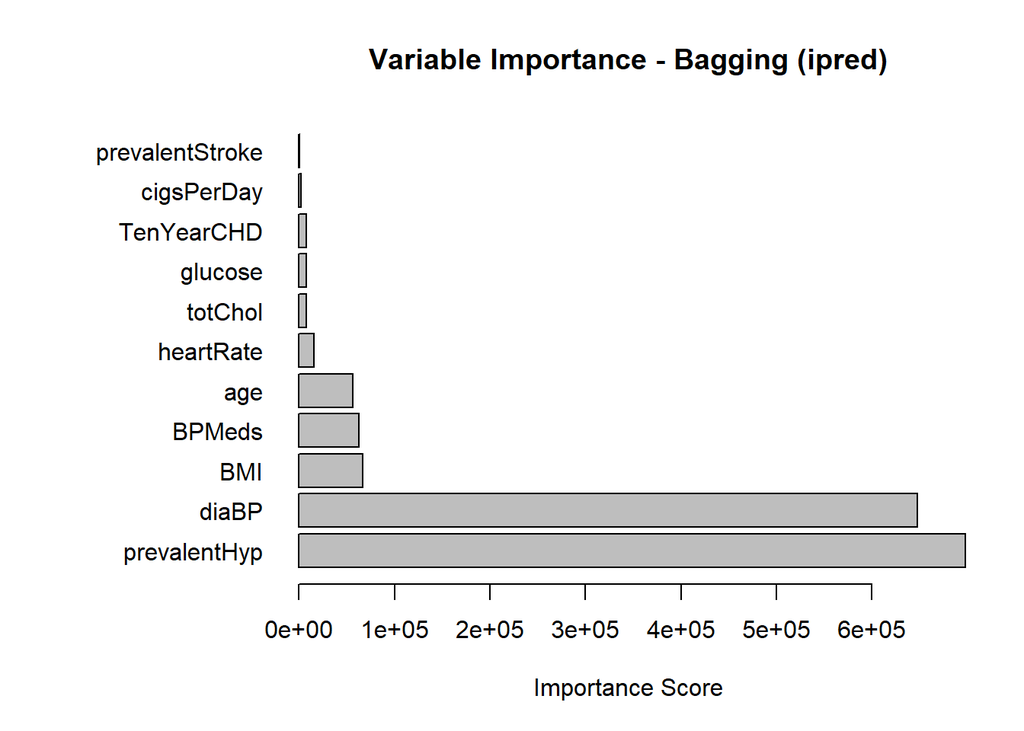

```r
# Get importance
importance.scores <- get.bagging.importance(final.model)

# Set plot margins (bottom, left, top, right)
par(mar = c(5, 10, 4, 2))  # Increase left margin from default (usually 4.1) to 10

# Sort and plot
importance.scores <- sort(importance.scores, decreasing = TRUE)
barplot(importance.scores, horiz = TRUE, las = 1,
        main = "Variable Importance - Bagging (ipred)",
        xlab = "Importance Score")
```

## 5.4 Performance Comparison

Evaluating the performance of the bagged tree model against two benchmark models: + An optimized base regression tree + Standard Gaussian linear regression model.

The following comparison assesses their predictive accuracy on the test set

```r
# Remove rows with any NA
train.data.clean <- na.omit(train.data)
test.data.clean <- test.data[, colnames(train.data.clean)]
test.data.clean <- na.omit(test.data.clean)

## ordinary LSE regression model with step-wise variable selection
lse.fit <- lm(sysBP~.,data = train.data.clean)
AIC.fit <- stepAIC(lse.fit, direction="both", trace = FALSE)
##
pred.lse <- predict(AIC.fit, test.data.clean)
mae.lse <- mean(abs(test.data.clean$sysBP - pred.lse)) # mean absolutesquare error
mse.lse <- mean((test.data.clean$sysBP - pred.lse)^2)  # mean square error
rmse.lse <- sqrt(mse.lse)                       # root mean square error
r.squared.lse <- (cor(test.data.clean$sysBP, pred.lse))^2 # r-squared
##
# Base regression tree
tree.model <- rpart(sysBP ~ .,
                    data = train.data,
                    method = "anova",     # For regression
                    control = rpart.control(
                      minsplit = 20,    # 3. Stopping rule: min observations to split
                      minbucket = 7,    # Min observations in terminal node
                      cp = seq(0, 0.05, 20), # Complexity parameter
                      maxdepth = 5      # Maximum tree depth
                    ))
# cp table
cp.table <- tree.model$cptable
##
## Identify the minimum `xerror` and its `cp`.
min.xerror <- min(cp.table[, "xerror"])
min.cp.row <- which.min(cp.table[, "xerror"])
min.cp <- cp.table[min.cp.row, "CP"]
##
pruned.tree.min.cp <- prune(tree.model, cp = min.cp)
pred.min.cp <- predict(pruned.tree.min.cp, newdata = test.data)
##
# min.cp
mae.tree.min.cp <- mean(abs(test.data$sysBP - pred.min.cp))
mse.tree.min.cp <- mean((test.data$sysBP - pred.min.cp)^2)
rmse.tree.min.cp <- sqrt(mse.tree.min.cp)
r.squared.tree.min.cp <- cor(test.data$sysBP, pred.min.cp)^2
##
###
Errors <- cbind(MAE = c(baggedError[1], mae.tree.min.cp, mae.lse),
          RMSE = c(baggedError[3], rmse.tree.min.cp, rmse.lse),
          r.squared = c(baggedError[2], r.squared.tree.min.cp, r.squared.lse))
rownames(Errors) = c("bagged Tree", "tree.min.cp", "lse")
pander(Errors)
```

[output not shown]

# 6 BAGGING Classification

## 6.1 Hyperparameter Tuning

The hyperparameters to be tuned in BAGGING classification algorithms are

- nbagg: Number of bootstrap samples (trees)
- control: Parameters for the base learner (rpart in this case)
- minsplit: Minimum number of observations in a node before splitting
- maxdepth: Maximum depth of the tree
- cp: Complexity paramete

We calculate the values of the tuned hyperparamteres:

```r
data(data)

# Set seed for reproducibility
set.seed(12345)

# Split data into training and testing sets
trainIndex <- createDataPartition(data$TenYearCHD, p = 0.7, list = FALSE)
trainData <- data[trainIndex, ]
testData <- data[-trainIndex, ]

# Create a grid of hyperparameter combinations
hyper.grid <- expand.grid(
  nbagg = c(25, 50, 100),
  minsplit = c(5, 10, 20),
  maxdepth = c(5, 10, 20),
  cp = c(0.01, 0.001)
)

# Initialize a results data frame
results <- data.frame() # store values of tuned hyperparameters
best.accuracy <- 0      # store accuracy
best.params <- list()   # store best values of hyperparameter

# Loop through each hyperparameter combination
for(i in 1:nrow(hyper.grid)) {
  # Get current hyperparameters
  params <- hyper.grid[i, ]
}

# Set rpart control parameters
  rpart.control <- rpart.control(
    minsplit = params$minsplit,
    maxdepth = params$maxdepth,
    cp = params$cp
  )

    # Train bagging model
  bag.model <- bagging(
    TenYearCHD ~ .,
    data = trainData,
    nbagg = params$nbagg,
    coob = TRUE,
    control = rpart.control
  )

  # Make predictions: default cut-off 0.5
  preds <- predict(bag.model, newdata = testData)



preds_binary <- ifelse(preds >= 0.3, 1, 0)

# Check the minimum, maximum, and summary of the predicted probabilities
#summary(preds)

# Check how many predictions are above and below 0.5
#sum(preds >= 0.3)  # Number of predictions >= 0.5 (classified as 1)
#sum(preds < 0.3)   # Number of predictions < 0.5 (classified as 0)

# Ensure preds_binary is a factor with levels 0 and 1
preds_binary <- factor(preds_binary, levels = c(0, 1))

# Set the levels of testData$TenYearCHD explicitly to 0 and 1
testData$TenYearCHD <- factor(testData$TenYearCHD, levels = c(1, 0))

# Re-run the confusion matrix
cm <- confusionMatrix(preds_binary, testData$TenYearCHD)
accuracy <- cm$overall["Accuracy"]

    # Store results
  results <- rbind(results, data.frame(
    nbagg = params$nbagg,
    minsplit = params$minsplit,
    maxdepth = params$maxdepth,
    cp = params$cp,
    Accuracy = accuracy
  ))
  # Update best parameters if current model is better
  if(accuracy > best.accuracy) {
   best.accuracy <- accuracy
  best.params <- params
  }

  pander(best.params)
```

|  | nbagg | minsplit | maxdepth | cp |
| --- | --- | --- | --- | --- |
| **54** | 100 | 20 | 20 | 0.001 |

## 6.2 Train Final Model With Best Hyperparameters

```r
# Set rpart control with best parameters
best.control <- rpart.control(
  minsplit = best.params$minsplit,
  maxdepth = best.params$maxdepth,
  cp = best.params$cp
)

# Train final model
final.bag.model <- bagging(
  diabetes ~ .,
  data = trainData,
  nbagg = best.params$nbagg,
  coob = TRUE,
  control = best.control
)

# Set the levels of testData$TenYearCHD explicitly to 0 and 1
testData$TenYearCHD <- factor(testData$TenYearCHD, levels = c(1, 0))

# Evaluate on test set
final.preds <- predict(final.bag.model, newdata = testData)

final_preds_binary <- ifelse(preds >= 0.3, 1, 0)

# Ensure preds_binary is a factor with levels 0 and 1
final_preds_binary <- factor(final_preds_binary, levels = c(0, 1))

final.cm <- confusionMatrix(final_preds_binary, testData$TenYearCHD)
final.cm$table
```

```
          Reference
Prediction   1   0
         1  53 106
         0 142 971
```

we have the above confusion matrix. With the confusion matrix, we can calculate variable performance measures.

Global Measures and Comparisons

## 6.3 Comparing Models Performance

We will compare the BAGGING classification model with the base classification tree as well as the logistic regression model using ROC analysis and the area under the corresponding curves.

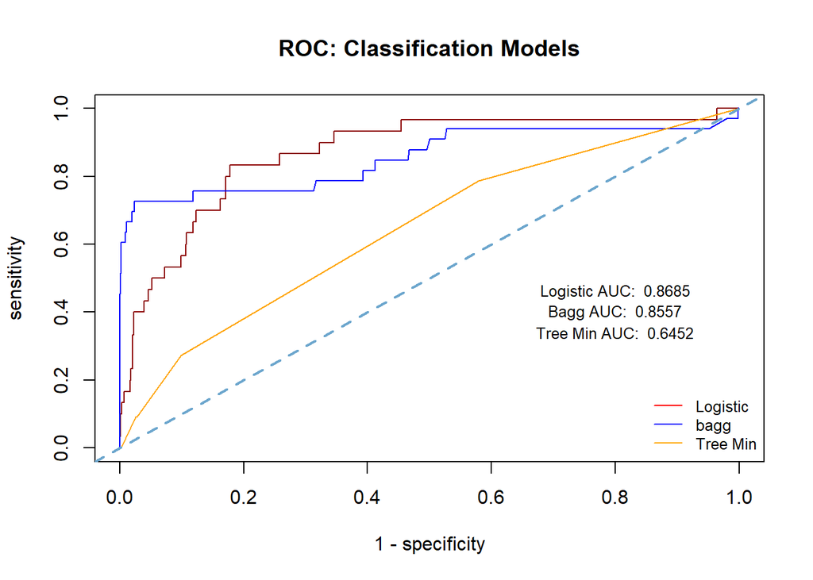

```r
########################
###  logistic regression
set.seed(12345)

# Remove rows with any NA
train.data.clean <- na.omit(train.data)

logit.fit <- glm(TenYearCHD ~ ., data = train.data.clean, family = binomial)
AIC.logit <- step(logit.fit, direction = "both", trace = 0)
pred.logit <- predict(AIC.logit, testData, type = "response")
##
# Build the initial classification tree
tree.model <- rpart(TenYearCHD ~ .,
                    data = trainData,
                    method = "class",   # classification tree
                    parms = list(split = "gini",  # Using Gini index
                                 # FN cost = 1, FP cost = 0.5
                                 loss = matrix(c(0, 0.3, 1, 0), nrow = 2)
                                 ),
                    control = rpart.control(minsplit = 15,  # Min 15 obs to split
                                           minbucket = 5,   # Min 7 obs in leaf
                                           # Complexity parameter
                                           cp = 0.001, # complex parameter
                                           maxdepth = 5))   # Max tree depth
###
min.cp <- tree.model$cptable[which.min(tree.model$cptable[,"xerror"]),"CP"]

# Prediction with three candidate models
pruned.tree.min <- prune(tree.model, cp = min.cp)
pred.prob.min <- predict(pruned.tree.min, testData, type = "prob")[,2]
pred.prob.bagg <- predict(final.bag.model, newdata = testData, type = "prob")
##

roc.tree.min <- roc(testData$diabetes, pred.prob.min)
roc.logit <- roc(testData$diabetes, pred.logit)
roc.bagg <- roc(testData$diabetes, pred.prob.bagg)


### Sen-Spe
bagg.sen <- roc.bagg$sensitivities
bagg.spe <- roc.bagg$specificities

#
tree.min.sen <- roc.tree.min$sensitivities
tree.min.spe <- roc.tree.min$specificities
#

logit.sen <- roc.logit$sensitivities
logit.spe <- roc.logit$specificities

## AUC
auc.bagg <- roc.bagg$auc
auc.tree.min <- roc.tree.min$auc
auc.logit <- roc.logit$auc

###
plot(1-logit.spe, logit.sen,
     xlab = "1 - specificity",
     ylab = "sensitivity",
     col = "darkred",
     type = "l",
     lty = 1,
     lwd = 1,
     main = "ROC: Classification Models")
lines(1-bagg.spe, bagg.sen,
      col = "blue",
      lty = 1,
      lwd = 1)
lines(1-tree.min.spe, tree.min.sen,
      col = "orange",
      lty = 1,
      lwd = 1)
abline(0,1, col = "skyblue3", lty = 2, lwd = 2)
legend("bottomright", c("Logistic", "bagg", "Tree Min"),
       lty = c(1,1,1), lwd = rep(1,3),
       col = c("red", "blue", "orange"),
       bty="n",cex = 0.8)
## annotation - AUC
text(0.8, 0.46, paste("Logistic AUC: ", round(auc.logit,4)), cex = 0.8)
text(0.8, 0.4, paste("Bagg AUC: ", round(auc.bagg,4)), cex = 0.8)
text(0.8, 0.34, paste("Tree Min AUC: ", round(auc.tree.min,4)), cex = 0.8)
```

In terms of model performance ranking, the logistic regression model is marginally better than Bagg model, while min tree model lagging behind.